# Titanic: Machine Learning from Disaster

```python
import numpy as np
import pandas as pd
import matplotlib.pyplot as plt
```

## Train Data Wrangling

### Overview

```python
train = pd.read_csv("./dataset/train.csv")

train
```

|  | PassengerId | Survived | Pclass | Name | Sex | Age | SibSp | Parch | Ticket | Fare | Cabin | Embarked |
| --- | --- | --- | --- | --- | --- | --- | --- | --- | --- | --- | --- | --- |
| 0 | 1 | 0 | 3 | Braund, Mr. Owen Harris | male | 22.0 | 1 | 0 | A/5 21171 | 7.2500 | NaN | S |
| 1 | 2 | 1 | 1 | Cumings, Mrs. John Bradley (Florence Briggs Th... | female | 38.0 | 1 | 0 | PC 17599 | 71.2833 | C85 | C |
| 2 | 3 | 1 | 3 | Heikkinen, Miss. Laina | female | 26.0 | 0 | 0 | STON/O2. 3101282 | 7.9250 | NaN | S |
| 3 | 4 | 1 | 1 | Futrelle, Mrs. Jacques Heath (Lily May Peel) | female | 35.0 | 1 | 0 | 113803 | 53.1000 | C123 | S |
| 4 | 5 | 0 | 3 | Allen, Mr. William Henry | male | 35.0 | 0 | 0 | 373450 | 8.0500 | NaN | S |
| ... | ... | ... | ... | ... | ... | ... | ... | ... | ... | ... | ... | ... |
| 886 | 887 | 0 | 2 | Montvila, Rev. Juozas | male | 27.0 | 0 | 0 | 211536 | 13.0000 | NaN | S |
| 887 | 888 | 1 | 1 | Graham, Miss. Margaret Edith | female | 19.0 | 0 | 0 | 112053 | 30.0000 | B42 | S |
| 888 | 889 | 0 | 3 | Johnston, Miss. Catherine Helen "Carrie" | female | NaN | 1 | 2 | W./C. 6607 | 23.4500 | NaN | S |
| 889 | 890 | 1 | 1 | Behr, Mr. Karl Howell | male | 26.0 | 0 | 0 | 111369 | 30.0000 | C148 | C |
| 890 | 891 | 0 | 3 | Dooley, Mr. Patrick | male | 32.0 | 0 | 0 | 370376 | 7.7500 | NaN | Q |

891 rows × 12 columns

### Suvived

[figure not shown]

```python
train_survived = train[train['Survived'] == 0].shape[0]
train_not_survived = train[train['Survived'] == 1].shape[0]

plt.pie([train_survived, train_not_survived], labels=['Survived: ' + str(train_survived), 'Not Survived: ' + str(train_not_survived)])

plt.show()
```

### Pclass

There are three different values of this field in train data.

```python
pd.DataFrame({ 'PClass': train.Pclass.unique()})
```

|  | PClass |
| --- | --- |
| 0 | 3 |
| 1 | 1 |
| 2 | 2 |

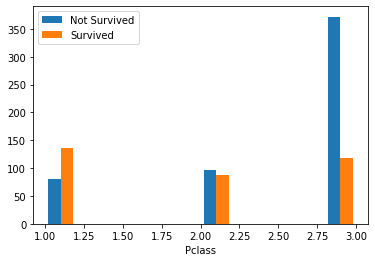

```python
ax = plt.subplot()

ax.hist([train[train.Survived == 0].Pclass, train[train.Survived == 1].Pclass], label=['Not Survived', 'Survived'])

ax.legend()

ax.set_xlabel('Pclass')

plt.show()
```

It it pretty clear that people with `Pclass = 1` have more possibility to survive. So we keep this feature `Pclass`.

### Name

First, vectorize the names.

```python
from sklearn.feature_extraction.text import CountVectorizer

name_vectorizer = CountVectorizer()

X = name_vectorizer.fit_transform(train.Name)
```

We got a sort of words.

```python
pd.DataFrame({ 'name': name_vectorizer.get_feature_names() })
```

|  | name |
| --- | --- |
| 0 | aaron |
| 1 | abbing |
| 2 | abbott |
| 3 | abelson |
| 4 | abraham |
| ... | ... |
| 1504 | zabour |
| 1505 | zebley |
| 1506 | zenni |
| 1507 | zillah |
| 1508 | zimmerman |

1509 rows × 1 columns

And a matrix of features.

```python
pd.DataFrame(X.toarray())
```

|  | 0 | 1 | 2 | 3 | 4 | 5 | 6 | 7 | 8 | 9 | ... | 1499 | 1500 | 1501 | 1502 | 1503 | 1504 | 1505 | 1506 | 1507 | 1508 |
| --- | --- | --- | --- | --- | --- | --- | --- | --- | --- | --- | --- | --- | --- | --- | --- | --- | --- | --- | --- | --- | --- |
| 0 | 0 | 0 | 0 | 0 | 0 | 0 | 0 | 0 | 0 | 0 | ... | 0 | 0 | 0 | 0 | 0 | 0 | 0 | 0 | 0 | 0 |
| 1 | 0 | 0 | 0 | 0 | 0 | 0 | 0 | 0 | 0 | 0 | ... | 0 | 0 | 0 | 0 | 0 | 0 | 0 | 0 | 0 | 0 |
| 2 | 0 | 0 | 0 | 0 | 0 | 0 | 0 | 0 | 0 | 0 | ... | 0 | 0 | 0 | 0 | 0 | 0 | 0 | 0 | 0 | 0 |
| 3 | 0 | 0 | 0 | 0 | 0 | 0 | 0 | 0 | 0 | 0 | ... | 0 | 0 | 0 | 0 | 0 | 0 | 0 | 0 | 0 | 0 |
| 4 | 0 | 0 | 0 | 0 | 0 | 0 | 0 | 0 | 0 | 0 | ... | 0 | 0 | 0 | 0 | 0 | 0 | 0 | 0 | 0 | 0 |
| ... | ... | ... | ... | ... | ... | ... | ... | ... | ... | ... | ... | ... | ... | ... | ... | ... | ... | ... | ... | ... | ... |
| 886 | 0 | 0 | 0 | 0 | 0 | 0 | 0 | 0 | 0 | 0 | ... | 0 | 0 | 0 | 0 | 0 | 0 | 0 | 0 | 0 | 0 |
| 887 | 0 | 0 | 0 | 0 | 0 | 0 | 0 | 0 | 0 | 0 | ... | 0 | 0 | 0 | 0 | 0 | 0 | 0 | 0 | 0 | 0 |
| 888 | 0 | 0 | 0 | 0 | 0 | 0 | 0 | 0 | 0 | 0 | ... | 0 | 0 | 0 | 0 | 0 | 0 | 0 | 0 | 0 | 0 |
| 889 | 0 | 0 | 0 | 0 | 0 | 0 | 0 | 0 | 0 | 0 | ... | 0 | 0 | 0 | 0 | 0 | 0 | 0 | 0 | 0 | 0 |
| 890 | 0 | 0 | 0 | 0 | 0 | 0 | 0 | 0 | 0 | 0 | ... | 0 | 0 | 0 | 0 | 0 | 0 | 0 | 0 | 0 | 0 |

891 rows × 1509 columns

Use k-means to cluster these features.

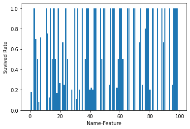

```python
from sklearn.cluster import KMeans

n_clusters = 500

name_cls = KMeans(n_clusters = n_clusters)

name_cls.fit(X)

train['Name-Feature'] = name_cls.predict(X)

ax = plt.subplot()

ax.bar(range(0, 100), [train[(train['Name-Feature'] == i) & (train['Survived'] == 1)].shape[0] / (train[train['Name-Feature'] == i].shape[0]) for i in range(0, 100)])

ax.set_ylabel('Suvived Rate')
ax.set_xlabel('Name-Feature')

plt.show()
```

At least we have a distribution of survied rate under different clusters. So we keep this generated field `Name-Feature`.

### Sex

There are two kinds of values of field `Sex` in train data.

```python
pd.DataFrame({ 'Sex': train.Sex.unique() })
```

|  | Sex |
| --- | --- |
| 0 | male |
| 1 | female |

Categorize the field `Sex`.

```python
train.loc[train.Sex == 'male', 'Male'] = 1
train.loc[train.Sex == 'female', 'Male'] = 0
```

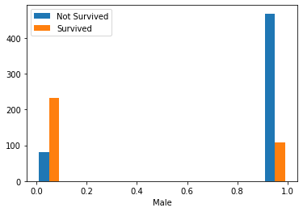

```python
ax = plt.subplot()

ax.hist([train[train.Survived == 0].Male, train[train.Survived == 1].Male], label=['Not Survived', 'Survived'])

ax.legend()

ax.set_xlabel('Male')

plt.show()
```

It is pretty clear that **females have more possibility to survive than males**. So we keep this field `Sex`.

### Age

The fields `Age` of some train instances are missed.

```python
pd.DataFrame({ 'Age': train.Age.unique() })
```

|  | Age |
| --- | --- |
| 0 | 22.00 |
| 1 | 38.00 |
| 2 | 26.00 |
| 3 | 35.00 |
| 4 | NaN |
| ... | ... |
| 84 | 0.67 |
| 85 | 30.50 |
| 86 | 0.42 |
| 87 | 34.50 |
| 88 | 74.00 |

89 rows × 1 columns

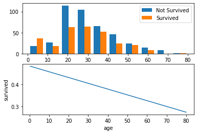

```
array([-0.00261254])
```

```python
from sklearn.linear_model import LinearRegression

train_with_age = train[train.Age.notna()]

fig, axes = plt.subplots(2)

axes[0].hist([train_with_age[train_with_age.Survived == 0].Age, train_with_age[train_with_age.Survived == 1].Age], label=['Not Survived', 'Survived'])

axes[0].legend()

axes[0].set_xlabel('Age')

reg = LinearRegression()

reg.fit(np.array(train_with_age.Age).reshape(-1, 1), train_with_age.Survived)

X = np.arange(train_with_age.Age.min(), train_with_age.Age.max(), 0.1)
Y = reg.predict(X.reshape(-1, 1))

axes[1].plot(X, Y)

axes[1].set_xlabel('age')
axes[1].set_ylabel('survived')

plt.show()

reg.coef_
```

In general, with increasing age, the survived rate shows a downward trend. So we keep this field `Age`.

And for the missing value of `Age`, we choose to use field `Pclass` to predict for a suitable value.

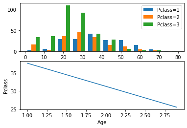

```python
from sklearn.linear_model import LinearRegression

train_with_age = train[train.Age.notna()]

fig, axes = plt.subplots(2)

axes[0].hist([
  train_with_age[train_with_age.Pclass == 1].Age,
  train_with_age[train_with_age.Pclass == 2].Age,
  train_with_age[train_with_age.Pclass == 3].Age], label=['Pclass=1', 'Pclass=2', 'Pclass=3'])

axes[0].legend()

axes[0].set_xlabel('Age')

reg_age = LinearRegression()

reg_age.fit(np.array(train_with_age.Pclass).reshape(-1, 1), train_with_age.Age)

X = np.arange(train_with_age.Pclass.min(), train_with_age.Pclass.max(), 0.1)
Y = reg_age.predict(X.reshape(-1, 1))

axes[1].plot(X, Y)

axes[1].set_xlabel('Age')
axes[1].set_ylabel('Pclass')


plt.show()
```

```python
if train[train.Age.isna()].shape[0] > 0:
  train.loc[train.Age.isna(), 'Age'] = reg_age.predict(np.array(train[train.Age.isna()].Pclass).reshape(-1, 1)).tolist()
```

### SibSp

The field `SibSp` indicates the number of family members aboard the Titanic. Thre are 7 possible values of the field `SibSp`.

```python
pd.DataFrame({ 'SibSp': train.SibSp.unique() })
```

|  | SibSp |
| --- | --- |
| 0 | 1 |
| 1 | 0 |
| 2 | 3 |
| 3 | 4 |
| 4 | 2 |
| 5 | 5 |
| 6 | 8 |

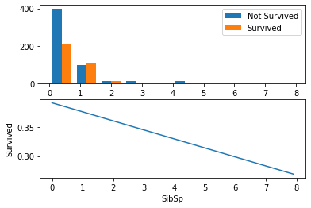

```python
from sklearn.linear_model import LinearRegression

fig, axes = plt.subplots(2)

axes[0].hist([
  train[train.Survived == 0].SibSp,
  train[train.Survived == 1].SibSp], label=['Not Survived', 'Survived'])

axes[0].legend()

axes[0].set_xlabel('SibSp')

reg = LinearRegression()

reg.fit(np.array(train.SibSp).reshape(-1, 1), train.Survived)

X = np.arange(train.SibSp.min(), train.SibSp.max(), 0.1)
Y = reg.predict(X.reshape(-1, 1))

axes[1].plot(X, Y)

axes[1].set_xlabel('SibSp')
axes[1].set_ylabel('Survived')


plt.show()
```

It seems that with increasing number of siblings, the survied rate is reduced. So we keep this field `SibSp`.

### Parch

The field `Parch` indicates the number of parents or children aboard the Titanic. There are also 7 possible values of this field.

```python
pd.DataFrame({ 'Parch': train.Parch.unique() })
```

|  | Parch |
| --- | --- |
| 0 | 0 |
| 1 | 1 |
| 2 | 2 |
| 3 | 5 |
| 4 | 3 |
| 5 | 4 |
| 6 | 6 |

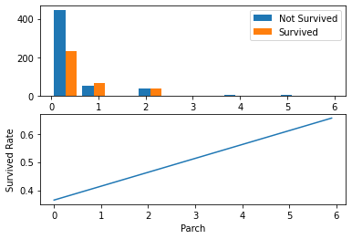

```python
from sklearn.linear_model import LinearRegression

fig, axes = plt.subplots(2)

axes[0].hist([
  train[train.Survived == 0].Parch,
  train[train.Survived == 1].Parch], label=['Not Survived', 'Survived'])

axes[0].legend()

axes[0].set_xlabel('Parch')

reg = LinearRegression()

reg.fit(np.array(train.Parch).reshape(-1, 1), train.Survived)

X = np.arange(train.Parch.min(), train.Parch.max(), 0.1)
Y = reg.predict(X.reshape(-1, 1))

axes[1].plot(X, Y)

axes[1].set_xlabel('Parch')
axes[1].set_ylabel('Survived Rate')


plt.show()
```

### Ticket

The field `Ticket` is the ticket number.

```python
pd.DataFrame({ 'Ticket': train.Ticket.unique() })
```

|  | Ticket |
| --- | --- |
| 0 | A/5 21171 |
| 1 | PC 17599 |
| 2 | STON/O2. 3101282 |
| 3 | 113803 |
| 4 | 373450 |
| ... | ... |
| 676 | SOTON/OQ 392076 |
| 677 | 211536 |
| 678 | 112053 |
| 679 | 111369 |
| 680 | 370376 |

681 rows × 1 columns

Vectorize this field and use k-means to generate a feature called `Ticket-Feature`.

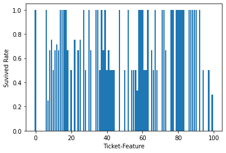

```python
from sklearn.feature_extraction.text import CountVectorizer
from sklearn.cluster import KMeans

ticket_vectorizer = CountVectorizer()

X = ticket_vectorizer.fit_transform(train.Ticket)

n_clusters = 500

ticket_cls = KMeans(n_clusters = n_clusters)

ticket_cls.fit(X)

train['Ticket-Feature'] = ticket_cls.predict(X)

ax = plt.subplot()

ax.bar(range(0, 100), [train[(train['Ticket-Feature'] == i) & (train['Survived'] == 1)].shape[0] / (train[train['Ticket-Feature'] == i].shape[0]) for i in range(0, 100)])

ax.set_ylabel('Suvived Rate')
ax.set_xlabel('Ticket-Feature')

plt.show()
```

At least we have a distribution of survied rate under different clusters. So we keep this generated field `Ticket-Feature`.

### Fare

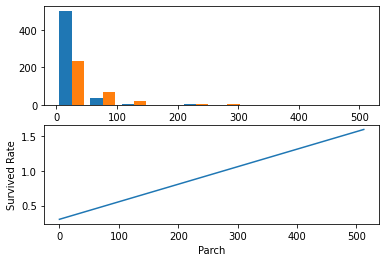

```python
fig, axes = plt.subplots(2)

axes[0].hist([
  train[train.Survived == 0].Fare,
  train[train.Survived == 1].Fare], label=['Not Survived', 'Survived'])

axes[0].set_xlabel('Fare')

reg = LinearRegression()

reg.fit(np.array(train.Fare).reshape(-1, 1), train.Survived)

X = np.arange(train.Fare.min(), train.Fare.max(), 0.1)
Y = reg.predict(X.reshape(-1, 1))

axes[1].plot(X, Y)

axes[1].set_xlabel('Parch')
axes[1].set_ylabel('Survived Rate')

plt.show()
```

### Cabin

Convert the field `Cabin` to `A-Z, -` and categorize.

```python
for i in range(ord('A'), ord('Z') + 1):
    train.loc[train.Cabin.notna() & train.Cabin.str.contains(chr(i)), 'Cabin'] = chr(i)

for i in range(ord('A'), ord('Z') + 1):
    train.loc[train.Cabin == chr(i), 'Cabin'] = i - ord('A')

if train[train.Cabin.isna()].shape[0] > 0:
    train.loc[train.Cabin.isna(), 'Cabin'] = -1
```

```python
train
```

|  | PassengerId | Survived | Pclass | Name | Sex | Age | SibSp | Parch | Ticket | Fare | Cabin | Embarked | Name-Feature | Male | Ticket-Feature |
| --- | --- | --- | --- | --- | --- | --- | --- | --- | --- | --- | --- | --- | --- | --- | --- |
| 0 | 1 | 0 | 3 | Braund, Mr. Owen Harris | male | 22.000000 | 1 | 0 | A/5 21171 | 7.2500 | -1 | S | 302 | 1.0 | 99 |
| 1 | 2 | 1 | 1 | Cumings, Mrs. John Bradley (Florence Briggs Th... | female | 38.000000 | 1 | 0 | PC 17599 | 71.2833 | 2 | C | 153 | 0.0 | 122 |
| 2 | 3 | 1 | 3 | Heikkinen, Miss. Laina | female | 26.000000 | 0 | 0 | STON/O2. 3101282 | 7.9250 | -1 | S | 4 | 0.0 | 186 |
| 3 | 4 | 1 | 1 | Futrelle, Mrs. Jacques Heath (Lily May Peel) | female | 35.000000 | 1 | 0 | 113803 | 53.1000 | 2 | S | 98 | 0.0 | 162 |
| 4 | 5 | 0 | 3 | Allen, Mr. William Henry | male | 35.000000 | 0 | 0 | 373450 | 8.0500 | -1 | S | 80 | 1.0 | 99 |
| ... | ... | ... | ... | ... | ... | ... | ... | ... | ... | ... | ... | ... | ... | ... | ... |
| 886 | 887 | 0 | 2 | Montvila, Rev. Juozas | male | 27.000000 | 0 | 0 | 211536 | 13.0000 | -1 | S | 380 | 1.0 | 329 |
| 887 | 888 | 1 | 1 | Graham, Miss. Margaret Edith | female | 19.000000 | 0 | 0 | 112053 | 30.0000 | 1 | S | 212 | 0.0 | 372 |
| 888 | 889 | 0 | 3 | Johnston, Miss. Catherine Helen "Carrie" | female | 24.815091 | 1 | 2 | W./C. 6607 | 23.4500 | -1 | S | 491 | 0.0 | 96 |
| 889 | 890 | 1 | 1 | Behr, Mr. Karl Howell | male | 26.000000 | 0 | 0 | 111369 | 30.0000 | 2 | C | 399 | 1.0 | 99 |
| 890 | 891 | 0 | 3 | Dooley, Mr. Patrick | male | 32.000000 | 0 | 0 | 370376 | 7.7500 | -1 | Q | 42 | 1.0 | 99 |

891 rows × 15 columns

### Embarked

The field `Embarked` indicates the place people aboard the Titanic. Some of them are missed.

```python
pd.DataFrame({ 'Embarked': train.Embarked.unique() })
```

|  | Embarked |
| --- | --- |
| 0 | S |
| 1 | C |
| 2 | Q |
| 3 | NaN |

[figure not shown]

```python
t = train[train.notna()]

for label in train.Embarked.unique():
    if not pd.isna(label):
        plt.bar(label, t[(t.Survived == 0) & (t.Embarked == label)].shape[0], label = label + ' / Survived')
        plt.bar(label, t[(t.Survived == 1) & (t.Embarked == label)].shape[0], label = label + ' / Not Survived')

plt.legend()

plt.show()
```

```python
train.groupby('Embarked').count()
```

| Embarked | PassengerId | Survived | Pclass | Name | Sex | Age | SibSp | Parch | Ticket | Fare | Cabin | Name-Feature | Male | Ticket-Feature |
| --- | --- | --- | --- | --- | --- | --- | --- | --- | --- | --- | --- | --- | --- | --- |
| C | 168 | 168 | 168 | 168 | 168 | 168 | 168 | 168 | 168 | 168 | 168 | 168 | 168 | 168 |
| Q | 77 | 77 | 77 | 77 | 77 | 77 | 77 | 77 | 77 | 77 | 77 | 77 | 77 | 77 |
| S | 644 | 644 | 644 | 644 | 644 | 644 | 644 | 644 | 644 | 644 | 644 | 644 | 644 | 644 |

Since the value `S` is the most common one, we choose `S` to fill in missied values.

```python
train.loc[train.Embarked.isna(), 'Embarked'] = 'S'
```

And also, categorize this field.

```python
train.loc[train.Embarked == 'C', 'Embarked'] = 0
train.loc[train.Embarked == 'Q', 'Embarked'] = 1
train.loc[train.Embarked == 'S', 'Embarked'] = 2
```

### Wrangled Train Data

Now, select choosen fields.

```python
train_x = train[['Pclass', 'Name-Feature', 'Male', 'Age', 'SibSp', 'Parch', 'Ticket-Feature', 'Fare', 'Cabin', 'Embarked']]

train_x = (train_x - train_x.min()) / (train_x.max() - train_x.min())

train_y = train.Survived

train_x
```

|  | Pclass | Name-Feature | Male | Age | SibSp | Parch | Ticket-Feature | Fare | Cabin | Embarked |
| --- | --- | --- | --- | --- | --- | --- | --- | --- | --- | --- |
| 0 | 1.0 | 0.605210 | 1.0 | 0.271174 | 0.125 | 0.000000 | 0.198397 | 0.014151 | 0 | 1 |
| 1 | 0.0 | 0.306613 | 0.0 | 0.472229 | 0.125 | 0.000000 | 0.244489 | 0.139136 | 0.15 | 0 |
| 2 | 1.0 | 0.008016 | 0.0 | 0.321438 | 0.000 | 0.000000 | 0.372745 | 0.015469 | 0 | 1 |
| 3 | 0.0 | 0.196393 | 0.0 | 0.434531 | 0.125 | 0.000000 | 0.324649 | 0.103644 | 0.15 | 1 |
| 4 | 1.0 | 0.160321 | 1.0 | 0.434531 | 0.000 | 0.000000 | 0.198397 | 0.015713 | 0 | 1 |
| ... | ... | ... | ... | ... | ... | ... | ... | ... | ... | ... |
| 886 | 0.5 | 0.761523 | 1.0 | 0.334004 | 0.000 | 0.000000 | 0.659319 | 0.025374 | 0 | 1 |
| 887 | 0.0 | 0.424850 | 0.0 | 0.233476 | 0.000 | 0.000000 | 0.745491 | 0.058556 | 0.1 | 1 |
| 888 | 1.0 | 0.983968 | 0.0 | 0.306548 | 0.125 | 0.333333 | 0.192385 | 0.045771 | 0 | 1 |
| 889 | 0.0 | 0.799599 | 1.0 | 0.321438 | 0.000 | 0.000000 | 0.198397 | 0.058556 | 0.15 | 0 |
| 890 | 1.0 | 0.084168 | 1.0 | 0.396833 | 0.000 | 0.000000 | 0.198397 | 0.015127 | 0 | 0.5 |

891 rows × 10 columns

## Test Data Wrangling

### Overview

```python
test = pd.read_csv('./dataset/test.csv')

test
```

|  | PassengerId | Pclass | Name | Sex | Age | SibSp | Parch | Ticket | Fare | Cabin | Embarked |
| --- | --- | --- | --- | --- | --- | --- | --- | --- | --- | --- | --- |
| 0 | 892 | 3 | Kelly, Mr. James | male | 34.5 | 0 | 0 | 330911 | 7.8292 | NaN | Q |
| 1 | 893 | 3 | Wilkes, Mrs. James (Ellen Needs) | female | 47.0 | 1 | 0 | 363272 | 7.0000 | NaN | S |
| 2 | 894 | 2 | Myles, Mr. Thomas Francis | male | 62.0 | 0 | 0 | 240276 | 9.6875 | NaN | Q |
| 3 | 895 | 3 | Wirz, Mr. Albert | male | 27.0 | 0 | 0 | 315154 | 8.6625 | NaN | S |
| 4 | 896 | 3 | Hirvonen, Mrs. Alexander (Helga E Lindqvist) | female | 22.0 | 1 | 1 | 3101298 | 12.2875 | NaN | S |
| ... | ... | ... | ... | ... | ... | ... | ... | ... | ... | ... | ... |
| 413 | 1305 | 3 | Spector, Mr. Woolf | male | NaN | 0 | 0 | A.5. 3236 | 8.0500 | NaN | S |
| 414 | 1306 | 1 | Oliva y Ocana, Dona. Fermina | female | 39.0 | 0 | 0 | PC 17758 | 108.9000 | C105 | C |
| 415 | 1307 | 3 | Saether, Mr. Simon Sivertsen | male | 38.5 | 0 | 0 | SOTON/O.Q. 3101262 | 7.2500 | NaN | S |
| 416 | 1308 | 3 | Ware, Mr. Frederick | male | NaN | 0 | 0 | 359309 | 8.0500 | NaN | S |
| 417 | 1309 | 3 | Peter, Master. Michael J | male | NaN | 1 | 1 | 2668 | 22.3583 | NaN | C |

418 rows × 11 columns

### Pclass

No missed values.

```python
pd.DataFrame({ 'Pclass': test.Pclass.unique() })
```

|  | Pclass |
| --- | --- |
| 0 | 3 |
| 1 | 2 |
| 2 | 1 |

### Name

Vectorize and cluster.

```python
X = name_vectorizer.transform(test.Name)

test['Name-Feature'] = name_cls.predict(X)
```

### Sex

No missed values.

```python
pd.DataFrame({ 'Sex': test.Sex.unique() })
```

|  | Sex |
| --- | --- |
| 0 | male |
| 1 | female |

Categorize.

```python
test.loc[test.Sex == 'male', 'Male'] = 1
test.loc[test.Sex == 'female', 'Male'] = 0
```

### Age

Use the field `Pclass` to predict missed values.

```python
if test[test.Age.isna()].shape[0] > 0:
  test.loc[test.Age.isna(), 'Age'] = reg_age.predict(np.array(test[test.Age.isna()].Pclass).reshape(-1, 1)).tolist()
```

### SibSp

```python
pd.DataFrame({ 'SibSp': test.SibSp.unique() })
```

|  | SibSp |
| --- | --- |
| 0 | 0 |
| 1 | 1 |
| 2 | 2 |
| 3 | 3 |
| 4 | 4 |
| 5 | 5 |
| 6 | 8 |

### Parch

```python
pd.DataFrame({ 'Parch': test.Parch.unique() })
```

|  | Parch |
| --- | --- |
| 0 | 0 |
| 1 | 1 |
| 2 | 3 |
| 3 | 2 |
| 4 | 4 |
| 5 | 6 |
| 6 | 5 |
| 7 | 9 |

### Ticket

Vectorize and cluster.

```python
X = ticket_vectorizer.transform(test.Ticket)

test['Ticket-Feature'] = ticket_cls.predict(X)
```

### Fare

Fill missed values with mean.

```python
if test[test.Fare.isna()].shape[0] > 0:
   test.loc[test.Fare.isna(), 'Fare'] = test.Fare.mean()
```

### Cabin

Convert the field `Cabin` to `A-Z, -` and categorize.

```python
for i in range(ord('A'), ord('Z') + 1):
    test.loc[test.Cabin.notna() & test.Cabin.str.contains(chr(i)), 'Cabin'] = chr(i)

for i in range(ord('A'), ord('Z') + 1):
    test.loc[test.Cabin == chr(i), 'Cabin'] = i - ord('A')

if test[test.Cabin.isna()].shape[0] > 0:
    test.loc[test.Cabin.isna(), 'Cabin'] = -1
```

### Embarked

No missed values.

```python
test.groupby('Embarked').count()
```

| Embarked | PassengerId | Pclass | Name | Sex | Age | SibSp | Parch | Ticket | Fare | Cabin | Name-Feature | Male | Ticket-Feature |
| --- | --- | --- | --- | --- | --- | --- | --- | --- | --- | --- | --- | --- | --- |
| C | 102 | 102 | 102 | 102 | 102 | 102 | 102 | 102 | 102 | 102 | 102 | 102 | 102 |
| Q | 46 | 46 | 46 | 46 | 46 | 46 | 46 | 46 | 46 | 46 | 46 | 46 | 46 |
| S | 270 | 270 | 270 | 270 | 270 | 270 | 270 | 270 | 270 | 270 | 270 | 270 | 270 |

Categorize.

```python
test.loc[test.Embarked == 'C', 'Embarked'] = 0
test.loc[test.Embarked == 'Q', 'Embarked'] = 1
test.loc[test.Embarked == 'S', 'Embarked'] = 2
```

### Wrangled Test Data.

Select choosen fields only and normalize.

```python
test_x = test[['Pclass', 'Name-Feature', 'Male', 'Age', 'SibSp', 'Parch', 'Ticket-Feature', 'Fare', 'Cabin', 'Embarked']]

test_x = (test_x - test_x.min()) / (test_x.max() - test_x.min())

test_x
```

|  | Pclass | Name-Feature | Male | Age | SibSp | Parch | Ticket-Feature | Fare | Cabin | Embarked |
| --- | --- | --- | --- | --- | --- | --- | --- | --- | --- | --- |
| 0 | 1.0 | 0.024540 | 1.0 | 0.452723 | 0.000 | 0.000000 | 0.197980 | 0.015282 | 0 | 0.5 |
| 1 | 1.0 | 0.026585 | 0.0 | 0.617566 | 0.125 | 0.000000 | 0.197980 | 0.013663 | 0 | 1 |
| 2 | 0.5 | 0.061350 | 1.0 | 0.815377 | 0.000 | 0.000000 | 0.197980 | 0.018909 | 0 | 0.5 |
| 3 | 1.0 | 0.584867 | 1.0 | 0.353818 | 0.000 | 0.000000 | 0.197980 | 0.016908 | 0 | 1 |
| 4 | 1.0 | 0.026585 | 0.0 | 0.287881 | 0.125 | 0.111111 | 0.270707 | 0.023984 | 0 | 1 |
| ... | ... | ... | ... | ... | ... | ... | ... | ... | ... | ... |
| 413 | 1.0 | 0.000000 | 1.0 | 0.325005 | 0.000 | 0.000000 | 0.197980 | 0.015713 | 0 | 1 |
| 414 | 0.0 | 0.000000 | 0.0 | 0.512066 | 0.000 | 0.000000 | 0.107071 | 0.212559 | 0.428571 | 0 |
| 415 | 1.0 | 0.826176 | 1.0 | 0.505473 | 0.000 | 0.000000 | 0.006061 | 0.014151 | 0 | 1 |
| 416 | 1.0 | 0.106339 | 1.0 | 0.325005 | 0.000 | 0.000000 | 0.197980 | 0.015713 | 0 | 1 |
| 417 | 1.0 | 0.020450 | 1.0 | 0.325005 | 0.125 | 0.111111 | 0.119192 | 0.043640 | 0 | 0 |

418 rows × 10 columns

## Performance Comparison

Now, we compare the performance of **Random Forest**, **Support Vector Machine** and **Multi-Layer Perceptron**.

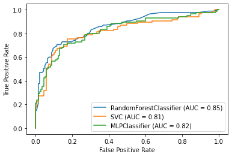

```python
from sklearn.neural_network import MLPClassifier
from sklearn.ensemble import RandomForestClassifier
from sklearn.svm import SVC
from sklearn.model_selection import train_test_split
from sklearn.metrics import plot_roc_curve

x1, x2, y1, y2 = train_test_split(train_x, train_y)

rfc = RandomForestClassifier()
svc = SVC()
mlp = MLPClassifier(max_iter=1000)

rfc.fit(x1, y1)
svc.fit(x1, y1)
mlp.fit(x1, y1)

ax = plt.gca()

plot_roc_curve(rfc, x2, y2, ax = ax)
plot_roc_curve(svc, x2, y2, ax = ax)
plot_roc_curve(mlp, x2, y2, ax = ax)

plt.show()
```

## Use Random Forest

```python
clf = RandomForestClassifier()

clf.fit(train_x, train_y)

test_y = clf.predict(test_x)

prediction = pd.DataFrame({ 'PassengerId': test.PassengerId, 'Survived': test_y })

prediction
```

|  | PassengerId | Survived |
| --- | --- | --- |
| 0 | 892 | 0 |
| 1 | 893 | 0 |
| 2 | 894 | 0 |
| 3 | 895 | 1 |
| 4 | 896 | 1 |
| ... | ... | ... |
| 413 | 1305 | 0 |
| 414 | 1306 | 1 |
| 415 | 1307 | 0 |
| 416 | 1308 | 0 |
| 417 | 1309 | 0 |

418 rows × 2 columns

## Save Result

```python
prediction.to_csv("./dataset/submission.csv", index = False)
```